# PA 9.1

## The Data

At this link, you will find a dataset containing information about heart disease patients: https://www.dropbox.com/scl/fi/0vrpdnq5asmeulc4gd50y/ha_1.csv?rlkey=ciisalceotl77ffqhqe3kujzv&dl=1

A description of the original dataset can be found here: https://archive.ics.uci.edu/dataset/45/heart+disease (However, this dataset has been cleaned and reduced, and the people have been given fictious names.)

```python
# Import Packages
import numpy as np
from sklearn.pipeline import Pipeline
from sklearn.compose import make_column_selector, ColumnTransformer
from sklearn.preprocessing import StandardScaler, OneHotEncoder
from sklearn.linear_model import LogisticRegression
from sklearn.discriminant_analysis import LinearDiscriminantAnalysis
from sklearn.svm import SVC
from sklearn.model_selection import cross_val_score, GridSearchCV
from plotnine import *
```

```python
# Import the data
import pandas as pd
df = pd.read_csv("https://www.dropbox.com/scl/fi/0vrpdnq5asmeulc4gd50y/ha_1.csv?rlkey=ciisalceotl77ffqhqe3kujzv&dl=1")
```

## 1. Logistic Regression

Fit a Logistic Regression using only `age` and `chol` (cholesterol) as predictors.

For a 55 year old, how high would their cholesterol need to be for the doctors to predict heart disease is present?

How high for the doctors to estimate a 90% chance that heart disease is present?

```python
# Separate predictors and outcome
X = df[["age", "chol"]]
y = df["diagnosis"]

logreg = LogisticRegression()
logreg.fit(X,y)
```

```
LogisticRegression()
```

```python
logreg.coef_
```

```
array([[0.04686331, 0.00180124]])
```

```python
# For a 55 year old, how high would their cholesterol need to be for the doctors to predict heart disease is present?
intercept = logreg.intercept_[0]
coef_age = logreg.coef_[0][0]
coef_chol = logreg.coef_[0][1]

target_age = 55

prob = (-intercept - (coef_age * target_age)) / coef_chol

prob
```

```
np.float64(367.8748897985677)
```

```python
# How high for the doctors to estimate a 90% chance that heart disease is present?
target_logit = np.log(0.9/(1-0.9))

chol_logreg90 = (target_logit - intercept - (coef_age *55)) / coef_chol
chol_logreg90
```

```
np.float64(1587.7158792754383)
```

## 2. Linear Discriminant Analysis

Fit an LDA model using only `age` and `chol` (cholesterol) as predictors.

For a 55 year old, how high would their cholesterol need to be for the doctors to predict heart disease is present?

```python
X = df[["age", "chol"]]
y = df["diagnosis"]

lda = LinearDiscriminantAnalysis()
lda.fit(X,y)
```

```
LinearDiscriminantAnalysis()
```

```python
lda.coef_
```

```
array([[0.04655744, 0.00178967]])
```

```python
# For a 55 year old, how high would their cholesterol need to be for the doctors to predict heart disease is present?
intercept = lda.intercept_[0]
coef_age = lda.coef_[0][0]
coef_chol = lda.coef_[0][1]

target_age = 55

prob = (-intercept - (coef_age * target_age)) / coef_chol

prob
```

```
np.float64(368.235357529938)
```

## 3. Support Vector Classifier

Fit an SVC model using only `age` and `chol` as predictors. Don’t forget to tune the regularization parameter.

For a 55 year old, how high would their cholesterol need to be for the doctors to predict heart disease is present?

```python
# Separate predictors and outcome
X = df[["age", "chol"]]
y = df["diagnosis"]

param_grid = {"svc__C": [0.01, 0.1, 1, 10, 100]}

svc_pipeline = Pipeline(
    [("standardize", StandardScaler()),
     ("svc", SVC(kernel="linear"))]
)

svc_model = GridSearchCV(svc_pipeline, param_grid, cv = 5)
svc_model.fit(X,y)

# Best fitted pipeline & SVC
best_pipe = svc_model.best_estimator_
best_svc = best_pipe.named_steps["svc"]
```

```python
best_svc.coef_
```

```
array([[0.60095567, 0.19360164]])
```

```python
# For a 55 year old, how high would their cholesterol need to be for the doctors to predict heart disease is present?
svc_age_coef = best_svc.coef_[0][0]
svc_chol_coef = best_svc.coef_[0][1]
svc_intercept = best_svc.intercept_[0]

target_age = 55

scaler = best_svc_model.named_steps['preprocessor'].named_transformers_['num'].named_steps['scaler']

mean_age = scaler.mean_[0]
std_age = scaler.scale_[0]
mean_chol = scaler.mean_[1]
std_chol = scaler.scale_[1]

scaled_target_age = (target_age - mean_age) / std_age

scaled_chol_boundary = (-svc_intercept - (svc_age_coef * scaled_target_age)) / svc_chol_coef

chol_boundary_svc = scaled_chol_boundary * std_chol + mean_chol

chol_boundary_svc
```

[output not shown]

## 4. Comparing Decision Boundaries

Make a scatterplot of `age` and `chol`, coloring the points by their true disease outcome. Add a line to the plot representing the **linear separator** (aka **decision boundary**) for each of the three models above.

```python
logreg_intercept = logreg.intercept_[0]
logreg_coef = logreg.coef_[0]

lda_intercept = lda.intercept_[0]
lda_coef = lda.coef_[0]

svc_intercept = best_svc.intercept_[0]
svc_coef = best_svc.coef_[0]

scaler = best_pipe.named_steps['standardize']
scaler_mean_age = scaler.mean_[0]
scaler_std_age = scaler.scale_[0]
scaler_mean_chol = scaler.mean_[1]
scaler_std_chol = scaler.scale_[1]
```

```python
plot_ages = np.linspace(df['age'].min(), df['age'].max(), 100)

# Calculate decision boundaries
logreg_db_chol = (-logreg_intercept - (logreg_coef[0] * plot_ages)) / logreg_coef[1]

lda_db_chol = (-lda_intercept - (lda_coef[0] * plot_ages)) / lda_coef[1]

scaled_plot_ages = (plot_ages - scaler_mean_age) / scaler_std_age
svc_scaled_db_chol = (-svc_intercept - (svc_coef[0] * scaled_plot_ages)) / svc_coef[1]
svc_db_chol = svc_scaled_db_chol * scaler_std_chol + scaler_mean_chol


# New df
logreg_df = pd.DataFrame({
    "age": plot_ages,
    "chol": logreg_db_chol,
    "model": "Logistic Regression"
})

lda_df = pd.DataFrame({
    "age": plot_ages,
    "chol": lda_db_chol,
    "model": "LDA"
})

svc_df = pd.DataFrame({
    "age": plot_ages,
    "chol": svc_db_chol,
    "model": "SVC"
})

decision_boundaries_df = pd.concat([logreg_df, lda_df, svc_df])

print(decision_boundaries_df.head())
```

```
         age         chol                model
0  29.000000  1044.323870  Logistic Regression
1  29.484848  1031.709437  Logistic Regression
2  29.969697  1019.095004  Logistic Regression
3  30.454545  1006.480570  Logistic Regression
4  30.939394   993.866137  Logistic Regression
```

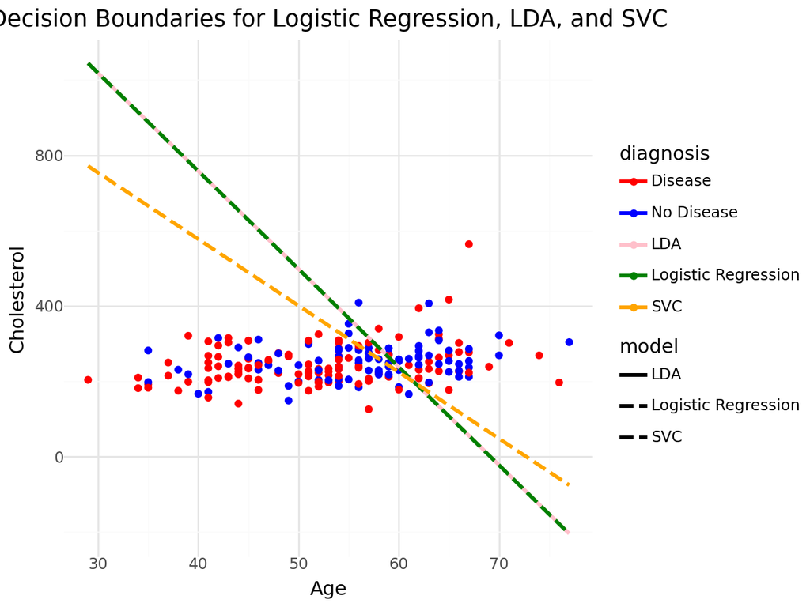

```python
scatter_plot = (
    ggplot(df, aes(x='age', y='chol', color='diagnosis'))
    + geom_point()
    + geom_line(aes(x='age', y='chol', color='model', linetype='model'), data=decision_boundaries_df, size=1.2)
    + labs(title='Decision Boundaries for Logistic Regression, LDA, and SVC', x='Age', y='Cholesterol')
    + scale_color_manual(values={'Disease': 'red', 'No Disease': 'blue', 'Logistic Regression': 'green', 'LDA': 'pink', 'SVC': 'orange'})
    + scale_linetype_manual(values={'Logistic Regression': 'dashed', 'LDA': 'solid', 'SVC': 'dashed'})
    + theme_minimal()
)

scatter_plot
```